# Plotting models with confidence (intervals)

Sam vanDeurs samantha.vandeurs@usys.ethz.ch

2023-09-15

#lab retreat 2023

```r
library(lmerTest)
```

```r
library(ggplot2)
library(Rmisc)
```

**This chunk of code can be converted into a function in the future, however I will proceed here with the hardcoded variables.**

Days_to_flowering: a continuous numeric and our response variable precip.wettest.month: a continuous numeric and one of our fixed effects Cohort: a factor with two levels (1976 and 2020) and one of our fixed effects Treatment: a factor with two levels (Control and drought) and one of our fixed efects Block: a factor with ten levels and a random effect Population.1: a factor with 21 levels and a random effect Load in the data and set the variables to the correct class for the model and plot.

```r
#read in data
data<-read.csv("/Users/Magnolia/lactuca_model_example.csv")# change to your location
data$Treatment<-as.factor(data$Treatment) # set to factor
data$Cohort<-as.factor(data$Cohort) # set to factor
data$Block<-as.factor(data$Block) # set to factor
data$Days_to_flowering<-as.numeric(data$Days_to_flowering) # Set to numeric
data$Precipitation.of.Wettest.Month<-as.numeric(data$Precipitation.of.Wettest.Month) # set to numeric
```

We can make mixed models of days to flowering by precipiation of the wettest month, cohort and treatment.

```r
# make  model
mod1 <- lmer(Days_to_flowering~ Precipitation.of.Wettest.Month + Cohort +Treatment + (1|Block)+  (1|Population.1), data = data)

#get the significance
anova(mod1)
```

```
## Type III Analysis of Variance Table with Satterthwaite's method
##                                Sum Sq Mean Sq NumDF  DenDF  F value    Pr(>F)
## Precipitation.of.Wettest.Month   2813    2813     1  19.66   8.1547  0.009885
## Cohort                           2238    2238     1 423.33   6.4880  0.011213
## Treatment                       52357   52357     1 423.28 151.7912 < 2.2e-16
##
## Precipitation.of.Wettest.Month **
## Cohort                         *
## Treatment                      ***
## ---
## Signif. codes:  0 '***' 0.001 '**' 0.01 '*' 0.05 '.' 0.1 ' ' 1
```

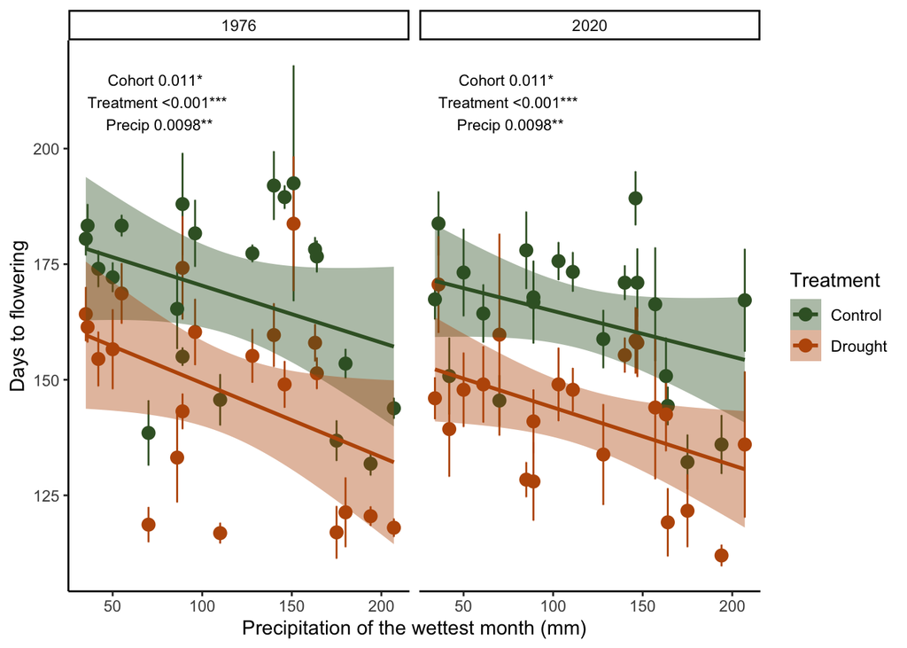

```r
#get the population means for plotting
data_summary <- summarySE(data=data, measurevar = "Days_to_flowering", groupvars = c("Population.1", "Cohort","Precipitation.of.Wettest.Month","Treatment"))

#assign colors to factors
col_years<-c("1976"="#627715","2020"="#F7A60F")
col_treat<-c("Drought"="#BC5707","Control"="#3B602F")

#plot the model
smooth.cohort.facet <- ggplot(data_summary, aes(x=Precipitation.of.Wettest.Month, y=Days_to_flowering, colour=Treatment, group=Treatment, label=Population.1))+
  #add error bars for population mean
  geom_errorbar(aes(colour=Treatment,ymin=Days_to_flowering-se, ymax=Days_to_flowering+se), width=.1) +
  #edit size of points
  geom_point(size=3)+
  #Add labels
  xlab("Precipitation of the wettest month (mm)") + ylab("Days to flowering")+
  #Fit the model
  geom_smooth(aes(color = Treatment, fill = Treatment),method = "lm", formula=y ~ x )+
  #Set the colors
  scale_color_manual(values=col_treat)+
  #set the fills
  scale_fill_manual(values=col_treat) +
  #separate by cohort
  facet_wrap(~Cohort)+
#add the significance text
  annotate("text", x=75, y=210, label= "Cohort 0.011* \n Treatment <0.001*** \n Precip 0.0098**" ,size = 3)+
  #set the plot theme
  theme_classic()
smooth.cohort.facet
```

[figure not shown]

```r
smooth.treatment.facet <- ggplot(data_summary, aes(x=Precipitation.of.Wettest.Month, y=Days_to_flowering, colour=Cohort, group=Cohort, label=Population.1))+
  geom_errorbar(aes(colour=Cohort,ymin=Days_to_flowering-se, ymax=Days_to_flowering+se), width=.1) +
  geom_point(size=3)+
  #geom_point(position=pd, size=3)+
  xlab("Precipitation of the wettest month (mm)") + ylab("Scaled fitness (Total seed mass)")+
  geom_smooth(aes(color = Cohort, fill = Cohort),method = "lm", formula=y ~ x )+
  scale_color_manual(values=col_years)+
  scale_fill_manual(values=col_years) +
  facet_wrap(~Treatment)+
#facet_grid(vars(Treatment), vars(group))+
  annotate("text", x=75, y=210, label= "Cohort 0.011* \n Treatment <0.001*** \n Precip 0.0098**" ,size = 3)+
  theme_classic()
smooth.treatment.facet
```

However, the line plotted here is the linear model generated by geom_smooth of the data plotted, in this case the population means, and does not represent the model we spent all this time perfecting and selecting for the entire data set.

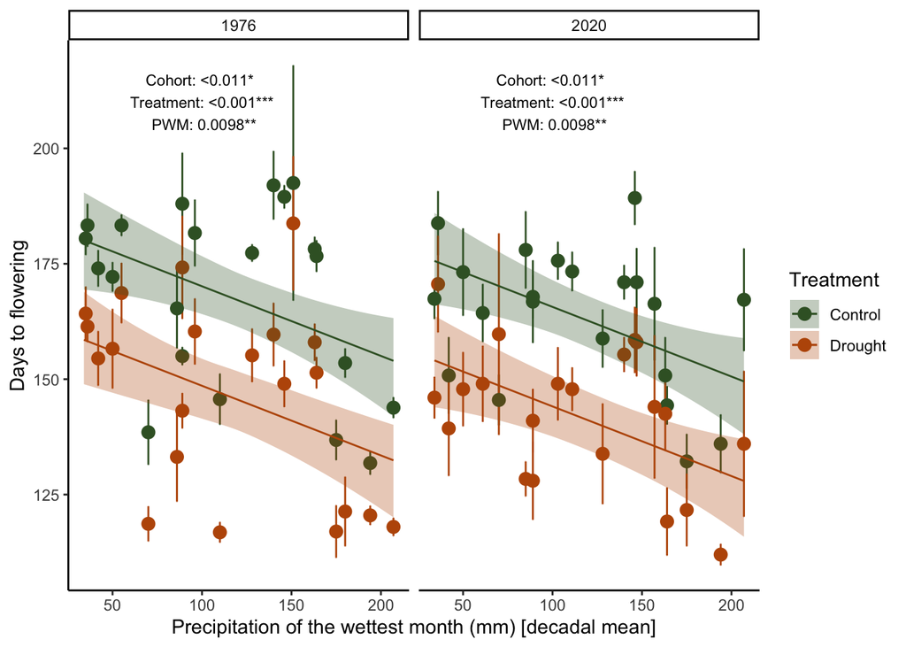

```r
data_summary <- summarySE(data=data, measurevar = "Days_to_flowering", groupvars = c("Population.1", "Cohort","Precipitation.of.Wettest.Month","Treatment"))

model_cohort_facet<-ggplot(data_summary, aes(x=Precipitation.of.Wettest.Month, y=Days_to_flowering, colour=Treatment, group=Treatment)) +
  geom_errorbar(aes(colour=Treatment,ymin=Days_to_flowering-se, ymax=Days_to_flowering+se), width=.1) +
  geom_point( size=3)+
  xlab("Precipitation of the wettest month (mm) [decadal mean]") + ylab("Days to flowering")+
geom_line(data = data_df_smoothed, aes(x=Precipitation.of.Wettest.Month, y=Days_to_flowering,
                               colour=Treatment, group=interaction(Cohort, Treatment))) +
  geom_ribbon(data = data_df_smoothed, aes(x=Precipitation.of.Wettest.Month, ymin=lwr, ymax=upr, fill=Treatment), alpha=0.3, color=NA) +
  facet_wrap(~Cohort)+
    scale_color_manual(values=col_treat)+
  scale_fill_manual(values=col_treat) +
   annotate("text", x=100, y=210, label= "Cohort: <0.011* \n Treatment: <0.001*** \n PWM: 0.0098**",size = 3)+
  theme_classic()
model_cohort_facet
```

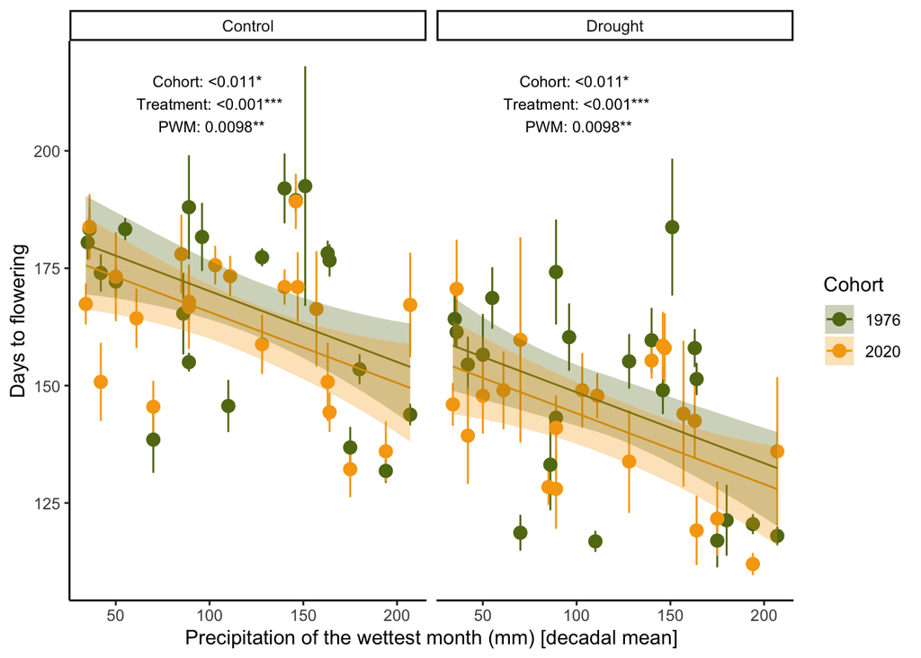

```r
model_treat_facet<-ggplot(data_summary, aes(x=Precipitation.of.Wettest.Month, y=Days_to_flowering, colour=Cohort, group=Cohort)) +
  geom_errorbar(aes(colour=Cohort,ymin=Days_to_flowering-se, ymax=Days_to_flowering+se), width=.1) +
  geom_point( size=3)+
  xlab("Precipitation of the wettest month (mm) [decadal mean]") + ylab("Days to flowering")+
geom_line(data = data_df_smoothed, aes(x=Precipitation.of.Wettest.Month, y=Days_to_flowering,
                               colour=Cohort, group=interaction(Cohort, Treatment))) +
  geom_ribbon(data = data_df_smoothed, aes(x=Precipitation.of.Wettest.Month, ymin=lwr, ymax=upr, fill=Cohort), alpha=0.3, color=NA) +
  facet_wrap(~Treatment)+
    scale_color_manual(values=col_years)+
  scale_fill_manual(values=col_years) +
   annotate("text", x=100, y=210, label= "Cohort: <0.011* \n Treatment: <0.001*** \n PWM: 0.0098**",size = 3)+
  theme_classic()
model_treat_facet
```

and for comparison the original plots

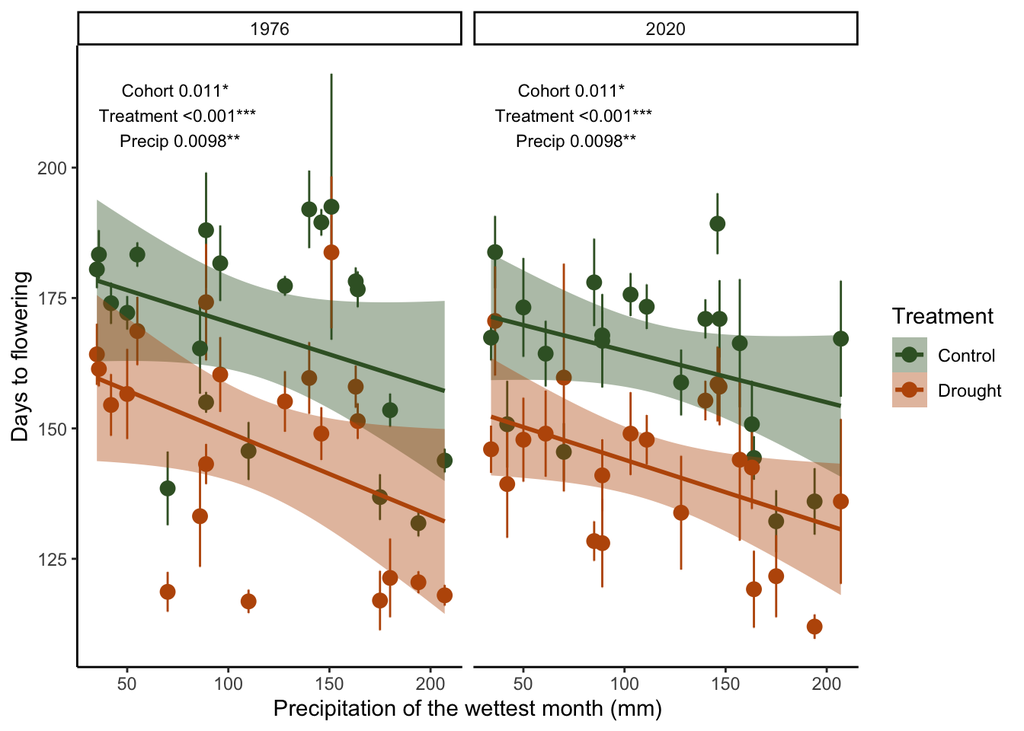

```r
# Plot of the
smooth.cohort.facet
```

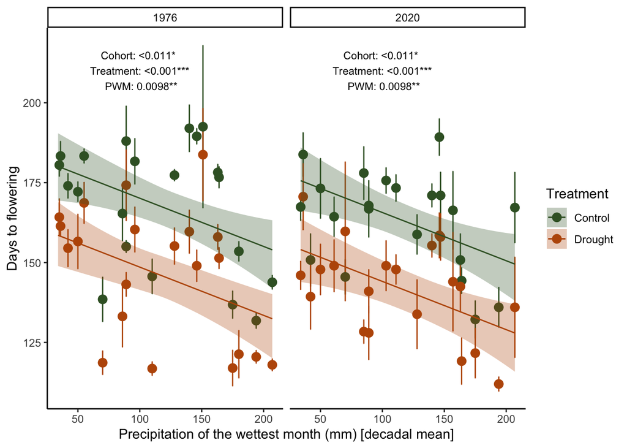

```r
#
model_cohort_facet
```

[figure not shown]

```r
#
smooth.treatment.facet
```

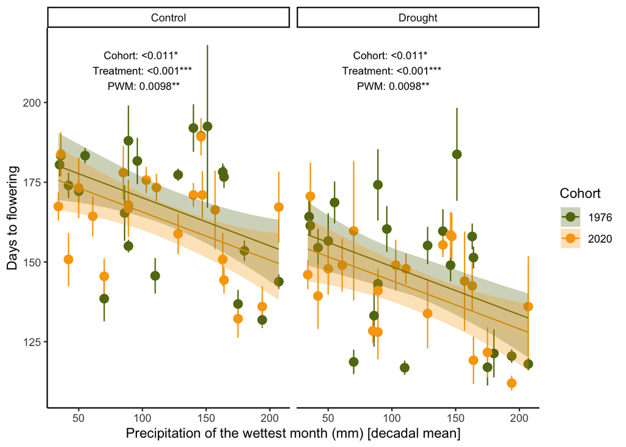

```r
#
model_treat_facet
```

While the differences in this examples are slight, in other cases the differences will be more noticeable. For example, here we have seed number data. The top image is data plotted in ggplot, and then fit with geom_smooth as above.

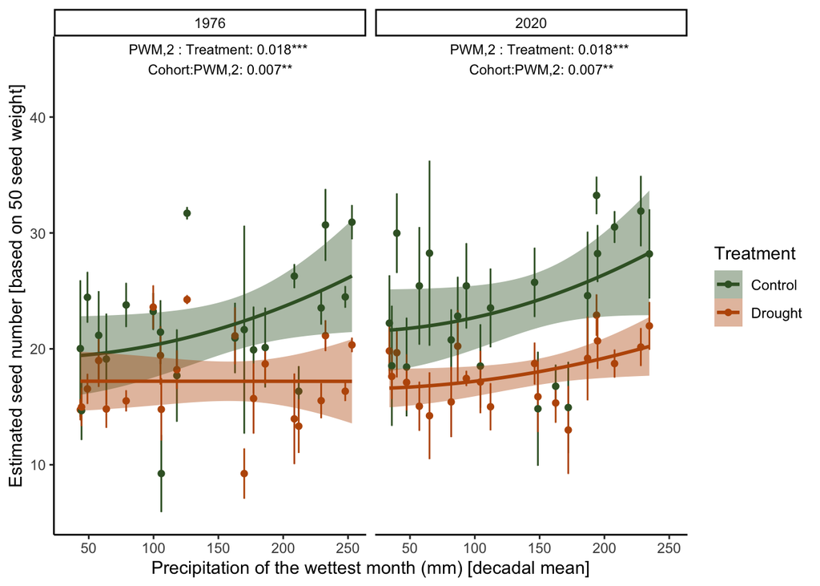

geom_smooth fit a line thorugh the means of my plotted data

And here we are plotting the actual model with the calculated 95% confidence intervals

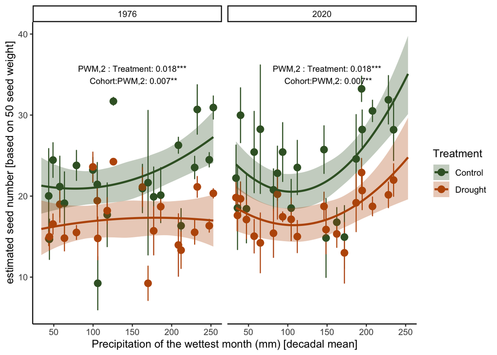

the plotted line is the model that we made, with the populaiton means plotted on top with the 95% confidence interval

What we plot can impact how we interpret the trends in our data.